# BES Analysis

Özge, Mustafa, Özgün, Sezer, Emir

11/9/2019

## Importing & Organizng Data

shineRs have collected data from EGM [website](https://www.egm.org.tr/) and stored it as an xlsx file. We then fed the excel file into R through the `read_excel` function. In order to analyze the data more effectively we cast the data from long to wide format.

The long format would designate observations in this manner:

| Company | Date | Explanation | Value |
| --- | --- | --- | --- |
| Anadolu | 2012-03-21 | “Devlet Katkisi Fon Tutari (TL)” | 38238 |
| Allianz | 2012-03-21 | “Emekli Olan Katilimci Sayisi” | 23823 |

Whereas the wide format would procure us with an orderly strucutre where variables are represented on columns and observations on rows:

| Company | Date | “Devlet Katkisi Fon Tutari (TL)” | “Emekli Olan Katilimci Sayisi” |
| --- | --- | --- | --- |
| Anadolu | 2012-03-21 | 38238 | 23823 |
| Allianz | 2012-04-21 | 23880 | 23028 |

```r
library(readxl)
library(lubridate)
library(reshape2)
library(tidyverse)
library(scales)

ext <- read_excel("31_07_2019_Oncesi_Rapor_Datasi_BES.xlsx")

ext2 <- ext %>%   mutate_if(~sum(is.na(.x)) > 0,
                    ~if_else(is.na(.x), "_", as.character(.x)))

ext2$ACIKLAMA <- paste0(ext2$TITLE2,ext2$ACIKLAMA)

ext2 <- ext2[rowSums(is.na(ext)) != ncol(ext), ]
ext2 <- ext2[ ,!(names(ext2) %in% "TITLE2")]
ext2 %>% mutate(RAPORTAR = ymd(RAPORTAR))
ext2$DEGER <- sapply(ext2$DEGER,as.numeric)

ext2 <- dcast(ext2,RAPORTAR+SIRKET ~ACIKLAMA, value.var = "DEGER", fun.aggregate = sum)

names(ext2) <- c("Rapor_tarihi",
                 "Sirket",
                 "Devlet Katkisi Fon Birikimi (TL)",
                 "Devlet Katkisi Fon Tutari (TL)",
                 "Emekli Olan Katilimci Sayisi",
                 "Katilimci Sayisi",
                 "Katilimcilarin Fon Tutari (TL)",
                 "Katki Payi Tutari (TL)",
                 "SS_Emeklilik Sözlesmeleri",
                 "SS_Gruba Bagli Bireysel Emeklilik Sözlesmeleri",
                 "SS_Grup Emeklilik Sözlesmeleri",
                 "SS_Isveren Grup Emeklilik Sertifikalari",
                 "SS_Toplam",
                 "YYT_Bireysel Emeklilik Sözlesmeleri (TL)",
                 "YYT_Gruba Bagli Bireysel Emeklilik Sözlesmeleri (TL)",
                 "YYT_Grup Emeklilik Sözlesmeleri (TL)",
                 "YYT_Isveren Grup Emeklilik Sertifikalari (TL)",
                 "YYT_Toplam (TL)" )
```

## Analysis & Graphs

### Number of participants hasincreased every year since 2004

As it can be seen from Katilimci Sayisi graph, from 2004 to 2018 the number of participants in the private pension system increased regularly. This increase started to be particularly remarkable after 2012. The fact that the state started to contribute to the funds since 2013 may be one of the reasons.

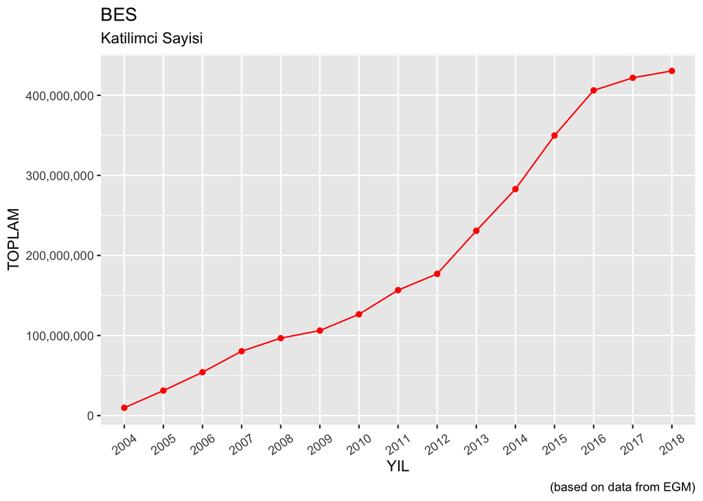

### Top 5 companies in the sector

When the top 5 companies in the sector are examined from Katilimci Sayisi ve Fon Tutari graph, Garanti Pension, Anadolu Hayat Emeklilik and Avivasa Emeklilik stand out in the number of participants and funds. While the number of participants of Anadolu Hayat Emeklilik and Garanti Emeklilik companies is approximately equal, Anadolu Hayat has managed to raise higher funds.

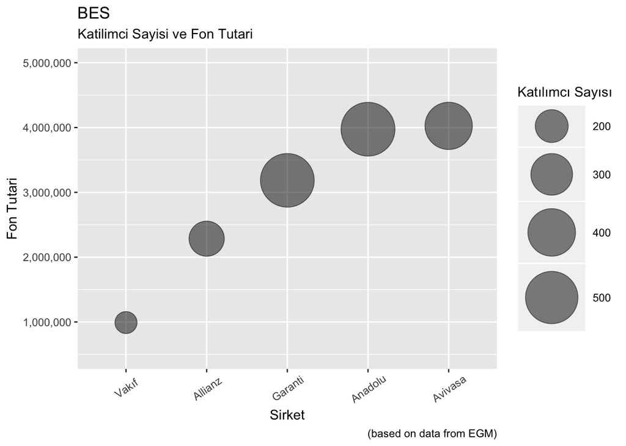

### Average Progression of Funds per Capita

When the top 5 companies in the sector are examined, the yearly development of average fund per individual, from 2004 to 2019, indicates that there is a wider gap among companies. As it can be observed below, currently “Avivasa” has the biggest and “Garanti” has the smallest average.

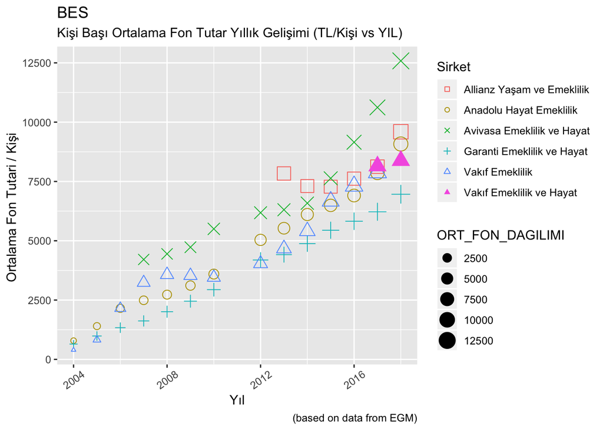

### The Rate of Pension Contracts over Total Contracts

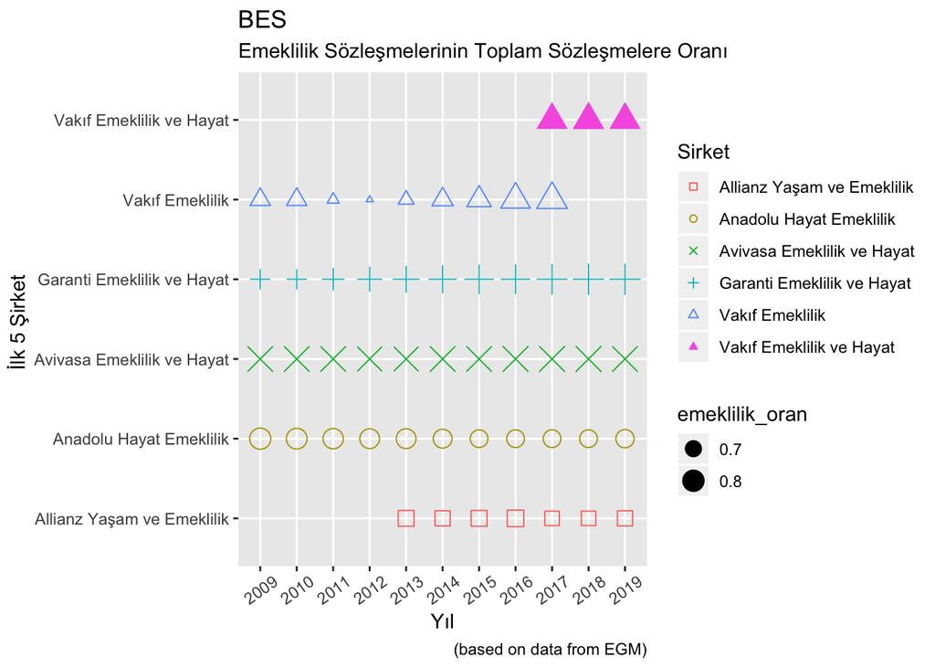